# Bayesian GAM Part3

Author

Murray Logan

Published

25/09/2026

# 1 Preparations

Load the necessary libraries

```r
library(tidyverse)  #for data wrangling etc
library(cmdstanr)   #for cmdstan
library(brms)       #for fitting models in STAN
library(standist)   #for exploring distributions
library(coda)       #for diagnostics
library(bayesplot)  #for diagnostics
library(ggmcmc)     #for MCMC diagnostics
library(DHARMa)     #for residual diagnostics
library(rstan)      #for interfacing with STAN
library(emmeans)    #for marginal means etc
library(broom)      #for tidying outputs
library(tidybayes)  #for more tidying outputs
library(HDInterval) #for HPD intervals
library(ggeffects)  #for partial plots
library(broom.mixed)#for summarising models
library(posterior)  #for posterior draws
library(ggeffects)  #for partial effects plots
library(patchwork)  #for multi-panel figures
library(bayestestR) #for ROPE
library(see)        #for some plots
library(easystats)     #framework for stats, modelling and visualisation
library(mgcv)
library(gratia)
theme_set(theme_grey()) #put the default ggplot theme back
source('helperFunctions.R')
```

# 2 Scenario

The Australian Institute of Marine Science (AIMS) have a long-term inshore marine water quality monitoring program in which water samples are collected and analysed from sites (reef.alias) across the GBR numerous times per year. The focus of this program is to report long-term condition and change in water quality parameters.

Although we do have latitude and longitudes, the nature of the spatial design predominantly reflects a series of transects that start near the mouth of a major river and extend northwards, yet mainly within the open coastal zone. As a result, this design is not well suited to any specific spatial analyses (since they are mainly one dimensional).

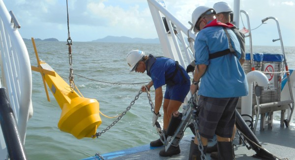

**Figure** 1: AIMS water quality monitoring

**Table** 1: Format of aims.wq.csv data file

| LATITUDE | LONGITUDE | reef.alias | Water_Samples | Region | Subregion | Season | waterYear | NOx |
| --- | --- | --- | --- | --- | --- | --- | --- | --- |
| -16.1 | 145. | Cape Trib… | AIMS | Wet T… | Barron D… | Dry | 2008 | 0.830 |
| -16.1 | 145. | Cape Trib… | AIMS | Wet T… | Barron D… | Wet | 2008 | 0.100 |
| -16.1 | 145. | Cape Trib… | AIMS | Wet T… | Barron D… | Dry | 2009 | 0.282 |
| -16.1 | 145. | Cape Trib… | AIMS | Wet T… | Barron D… | Wet | 2009 | 1.27 |
| -16.1 | 145. | Cape Trib… | AIMS | Wet T… | Barron D… | Dry | 2009 | 0.793 |
| -16.1 | 145. | Cape Trib… | AIMS | Wet T… | Barron D… | Dry | 2010 | 0.380 |
| ... | ... | ... | ... | ... | ... | ... | ... | ... |

**Table** 2: Description of the variables in the aims data file

| **LATITUDE** | - Latitudinal coordinate |
| --- | --- |
| **LONGITUDE** | - Longitudinal coordinate |
| **reef.alias** | - Internal AIMS reef name |
| **Water_Samples** | - Categorical label of who collected the data |
| **Region** | - The MMP region |
| **Subregion** | - The MMP subregion |
| **Season** | - A categorical listing of Wet or Dry |
| **waterYear** | - The water year (1st Oct - 30 Sept) to which the data are attached |
| **Date** | - The date the sample was collected |
| **Mnth** | - The month the sample was collected |
| **NOx** | - Nitrite and Nitrate |

# 3 Read in the data

```r
wq <- read_csv("../data/aims_wq.csv", trim_ws = TRUE)
```

We will start by defining each of the categorical variables as factors. We will also define the random effect (reef.alias) as a factor.

```r
wq <- wq |>
    mutate(
        Site = factor(Site),
        Region = factor(Region),
        Subregion = factor(Subregion),
        Season = factor(Season)
    )
```

# 4 Exploratory data analysis

Model formula:
$$\begin{align}
y_i &\sim{} \mathcal{N}(\mu_i, \sigma^2)\\
\mu_i &=\beta_0 + f(Date_i) + f(Month_i)
\end{align}$$

where $\beta_0$ is the y-intercept. $f(Date)$ and $f(Month)$ indicate the additive smoothing functions of the long-term temporal trends and the annual seasonal trends respectively.

If we begin with a quck scatterplot of NOx agains Date..

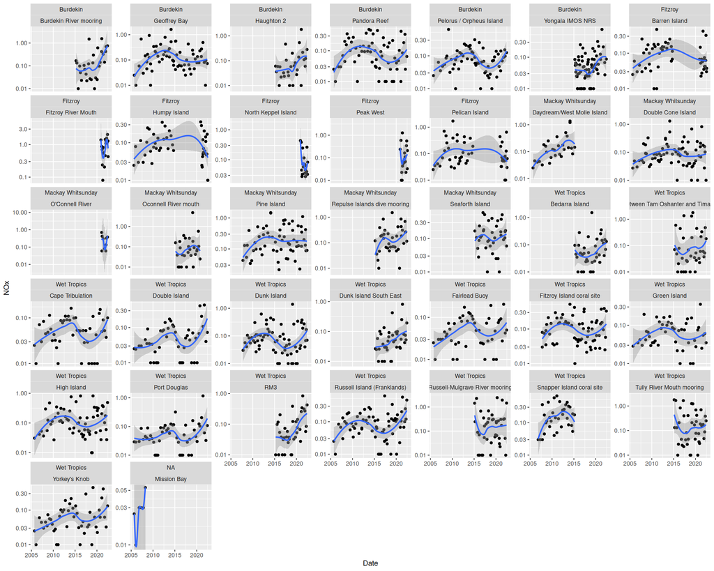

```r
wq |> ggplot(aes(y = NOx, x = Date)) +
    geom_point() +
    scale_y_log10() +
  facet_wrap(~ Region + Site, scales = "free_y") +
  geom_smooth()
```

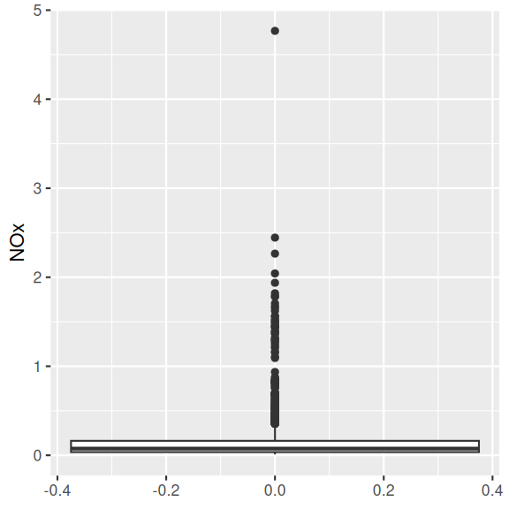

```r
wq |> ggplot(aes(y = NOx)) +
    geom_boxplot()
```

We know that these NOx values have been measured over time from a number of locations (reef.alias). Therefore, it would be good to facet the scatterplot conditional on the reef.alias.

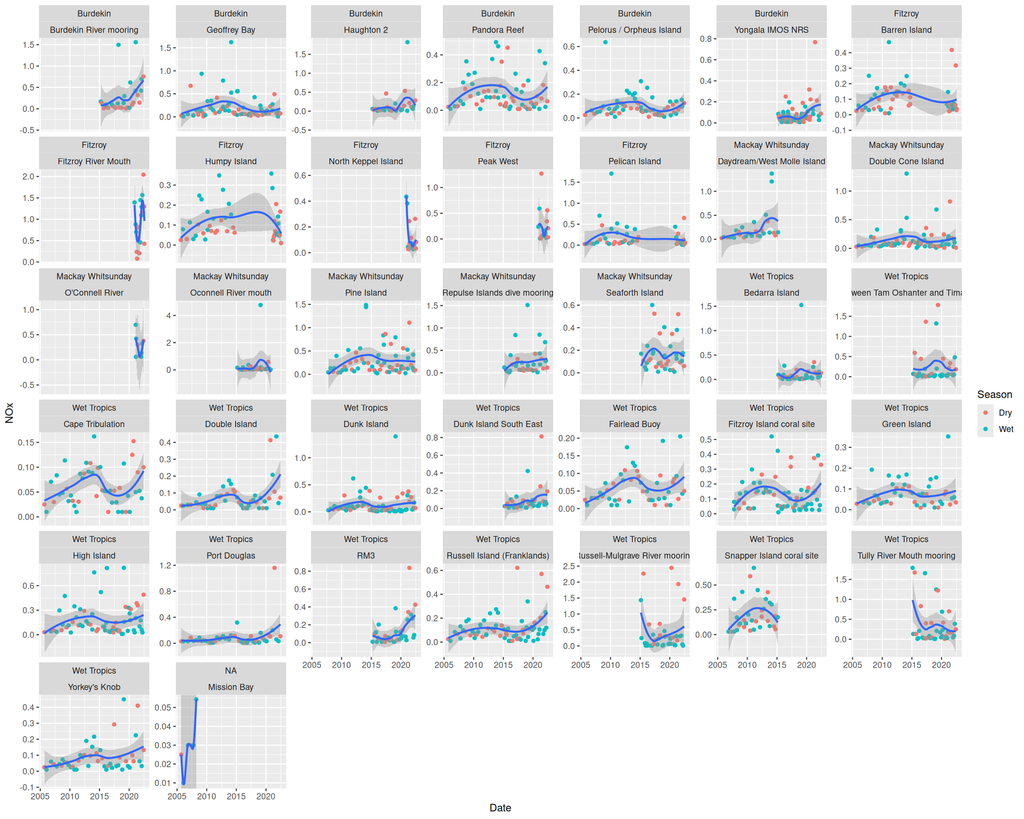

```r
ggplot(wq, aes(y = NOx, x = Date)) +
    geom_point(aes(colour = Season)) +
    geom_smooth() +
    facet_wrap(~Region + Site, scales = 'free_y')
```

**Conclusions:**

- evidently, some locations (reef.alias) have longer time series than others
- the amount and variability of NOx also varies greatly between locations.
- the temporal trends are clearly not linear and possibly more complex than simple polynomials - it is likely that splines will be useful
- assumptions of normality are difficult to assess, however it would seem logical that the data will not follow a Gaussian distribution (since values less than 0 are not possible and it does appear that there is a relationship between mean and variance).
- although not immediately obvious from some of the trends, the values of NOx appear to be truncated at 0.01. Indeed the limit of detection is 0.01 and thus values are capped at this value.

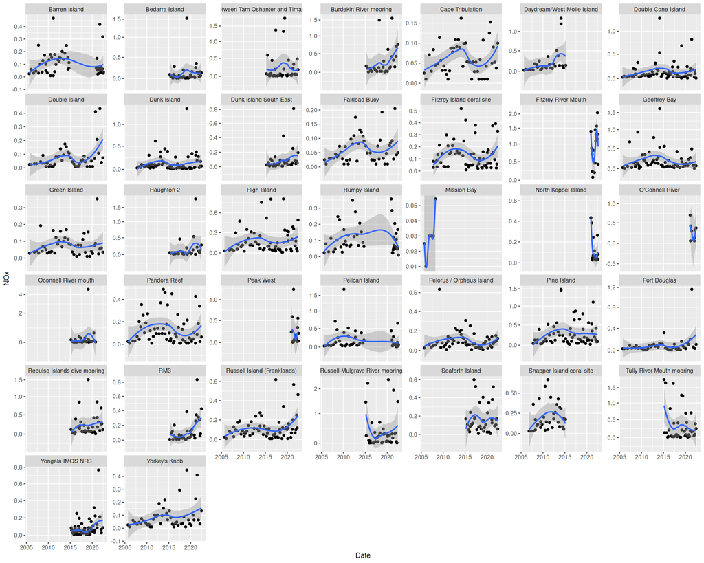

```r
ggplot(wq, aes(y=NOx, x=Date)) +
  geom_point() +
  geom_smooth() +
    scale_y_log10() +
  scale_y_continuous(trans=scales::pseudo_log_trans()) +
  facet_wrap(~Site,  scales='free_y')
```

**Conclusions:**

- although the loess smoothers are not particularly appropriate for non-Gaussian data, they nevertheless help us see that there are both similarities and differnces in the trends between locations. Most of the locations that have a long time series show some sort of peak in NOx around about 2014

# 5 Data preparations

Care must be taken when using dates in a model. This is because they are stored either as number of seconds or the number of days that have elapsed since a particular time. Typically, this means that they are stored as very large numbers and any calculations that involve large numbers can quickly become too large to handle efficiently. Hence, it is often a good idea to convert dates/times into simpler numeric representations. This can be performed with the `decimal_date()` function within the `lubridate` package.

Although we generally want to scale any continuous predictors, it appears that doing so with Date objects has downstream issues - the models fit ok, but partial plots are displaced along the x-axis. So as an alternative either dont scale, or do so with a routine that does not automatically back-trasform (such as sjmisc::std or sjmisc::center).

At this point, we can also add a predictor for month so as to facilitate models that will detrend a temporal series into long-terms and annual cycles. Furthermore, we will also establish a flag variable to handle the truncated limit of detection values. This latter variable will contain the string “left” for any value that is set to the limit of detection/reporting and “none” for all other values.

```r
wq <-
  wq |>
    mutate(dt_num = lubridate::decimal_date(Date)) |>
    mutate(Mnth = month(Date)) |>
    mutate(NOx_flag = ifelse(NOx == 0.01, "left", "none"))
```

# 6 Simple model (Double Island)

## 6.1 Date (Dt_num) only

**Exploratory data analysis**

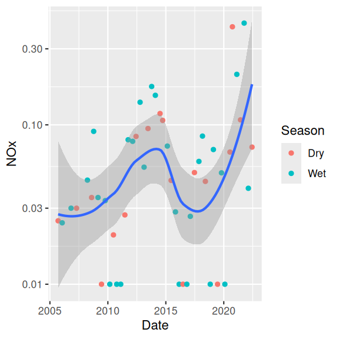

```r
wq_sub <-
  wq |>
  filter(Site == "Double Island") |>
  droplevels()

wq_sub |>
  ggplot(aes(y = NOx, x = Date)) +
  geom_point(aes(colour = Season)) +
  geom_smooth() +
  scale_y_log10()
```

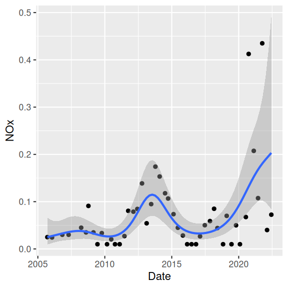

```r
wq_sub |>
  filter(!is.na(NOx)) |>
  ggplot(aes(y=NOx, x=Date)) +
  geom_point() +
  geom_smooth(method = 'gam', formula = y ~ s(x),
    method.args = list(family = Gamma(link = "log")))
```

```r
wq_sub |>
  pull(NOx) |>
  summary()
```

```
   Min. 1st Qu.  Median    Mean 3rd Qu.    Max.
0.01000 0.02482 0.04491 0.07197 0.08471 0.43500
```

**Conclusions:**

**GAM**

**Assessing default priors**

```r
wq_form <- bf(NOx | cens(NOx_flag) ~
                s(dt_num), family = Gamma(link = "log"))
get_prior(wq_form, data =  wq_sub)
```

```
                   prior     class      coef group resp dpar nlpar lb ub tag
                  (flat)         b
                  (flat)         b sdt_num_1
 student_t(3, -3.1, 2.5) Intercept
    student_t(3, 0, 2.5)       sds                                  0
    student_t(3, 0, 2.5)       sds s(dt_num)                        0
       gamma(0.01, 0.01)     shape                                  0
       source
      default
 (vectorized)
      default
      default
 (vectorized)
      default
```

```r
wq_brm <- brm(wq_form,
  data = wq_sub,
  prior = prior(normal(0, 2.5), class = 'b'),
  sample_prior = 'only',
  iter = 5000,
  warmup = 1000,
  chains = 3,
  thin = 5,
  seed = 123,
  backend = "rstan",
  refresh = 0)
```

##### conditional_effects

```
Ignoring unknown labels:
• fill : "NA"
• colour : "NA"
Ignoring unknown labels:
• fill : "NA"
• colour : "NA"
```

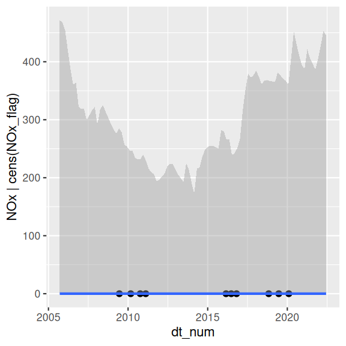

```
<ScaleContinuousPosition>
 Range:
 Limits:    0 --    1
```

```r
wq_brm |> conditional_effects() |>
  plot(points=TRUE) |>
  scale_y_log10()
```

**Defining priors**

The following link provides some guidance about defining priors. [https://github.com/stan-dev/stan/wiki/Prior-Choice-Recommendations]

**About priors**

I will also overlay the raw data for comparison.

sds- wiggliness parameter

A model such as

`y ~ s(scale(x))`

represents the relationship between `x` and `y` using a set of spline basis functions:

$$f(x)=\sum_{k=1}^{K} b_k B_k(x)$$

In `brms`, the spline is separated into:

- b: unpenalised components, including the broad linear trend
- sds: the standard deviation of the penalised spline coefficients, controlling departures from that trend

Conceptually, the penalised coefficients have a prior of the form
$$b_k^{\mathrm{smooth}} \sim \operatorname{Normal}(0,\sigma_s)$$

where $\sigma_s$ is reported as `sds`.

###### Prior for b

The `b` prior controls the size of the broad change in the response associated with the scaled predictor:

- a prior concentrated near zero favours a weak overall relationship
- a wider prior permits a stronger overall trend

Because `scale(x)` gives `x` mean zero and standard deviation one, `b` can be interpreted approximately as the expected change in the linear component of the response for a one-standard-deviation change in `x`.

Choose the prior using plausible effect sizes on the response scale. For example, if both `x` and `y` are standardised:

`prior(normal(0, 1), class = "b")` allows substantial positive or negative effects while mildly discouraging extremely large relationships.

If `y` is not standardised, select the prior scale in meaningful units of `y`. For example:

`prior(normal(0, 5), class = "b")`

says that changes of several response units per standard deviation of `x` are plausible.

###### Prior for sds

The `sds` parameter controls the complexity of the smooth:

- sds near zero favours an approximately linear relationship
- small sds permits gentle curvature
- large sds permits increasingly complex or wiggly relationships

Because sds must be positive, suitable weakly informative priors include half-normal, half-Student-ttt, and exponential distributions. For a standardised response, reasonable starting points are:

`prior(normal(0, 0.5), class = "sds")`

or, more permissively:

`prior(student_t(3, 0, 1), class = "sds")`

`brms` automatically constrains `sds` to be positive, so these become half-normal or half-Student-t priors.

A useful interpretation is:

- The prior on `sds` expresses how strongly we expect the relationship to depart from a straight line.

Note, `sds` does not correspond to a particular distance along `x`. Its effect depends on the spline basis dimension and the observed predictor values. It should therefore be checked using prior predictive smooths.

Practical guidelines:

| Prior choice | Interpretation |
| --- | --- |
| Narrower prior on b | Stronger belief that the overall relationship is weak |
| Wider prior on b | Allows a larger overall effect |
| —————————- | ——————————————————- |
| sds concentrated near zero | Favours an approximately linear relationship |
| Moderate prior on sds | Allows smooth curvature |
| Very broad prior on sds | Allows complex curves and may overfit sparse data |

**Sample prior only**

```r
wq_form <- bf(NOx | cens(NOx_flag) ~ s(scale(dt_num)), family = Gamma(link = "log"))

wq_sub |> summarise(
  median(log(NOx)),
  mad(log(NOx)),
  mad(log(NOx)) / mad(scale(dt_num))
)
```

```
# A tibble: 1 × 3
  `median(log(NOx))` `mad(log(NOx))` `mad(log(NOx))/mad(scale(dt_num))`
               <dbl>           <dbl>                              <dbl>
1              -3.10           0.925                              0.747
```

```r
get_prior(wq_form, data = wq_sub)
```

```
                   prior     class             coef group resp dpar nlpar lb ub
                  (flat)         b
                  (flat)         b   sscaledt_num_1
 student_t(3, -3.1, 2.5) Intercept
    student_t(3, 0, 2.5)       sds                                         0
    student_t(3, 0, 2.5)       sds s(scale(dt_num))                        0
       gamma(0.01, 0.01)     shape                                         0
 tag       source
          default
     (vectorized)
          default
          default
     (vectorized)
          default
```

```r
priors <- prior(normal(-3.1, 1),  class='Intercept') +
  prior(normal(0, 10), class='b') +
  prior(gamma(0.01, 0.01),  class='shape') +
  prior(student_t(3, 0, 10), class =  "sds")

wq_brm1 <- brm(wq_form,
                 data = wq_sub,
                 prior = priors,
                 sample_prior = 'only',
                 iter = 3000,
                 warmup = 1000,
                 thin = 5,
                 chains = 3, cores =  3,
                 backend = "rstan",
                 seed =  123,
                 control =  list(adapt_delta = 0.99, max_treedepth = 20),
                 refresh = 0)
```

```r
wq_brm1 |> conditional_effects() |>  plot(points=TRUE)
```

```
Ignoring unknown labels:
• fill : "NA"
• colour : "NA"
Ignoring unknown labels:
• fill : "NA"
• colour : "NA"
```

```
Ignoring unknown labels:
• fill : "NA"
• colour : "NA"
Ignoring unknown labels:
• fill : "NA"
• colour : "NA"
```

```
Ignoring unknown labels:
• fill : "NA"
• colour : "NA"
```

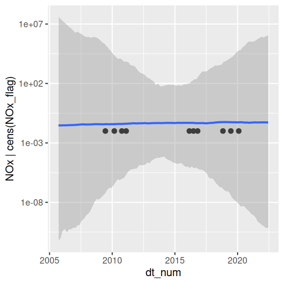

```r
wq_brm1 |> conditional_effects() |>  plot(points=TRUE) |>
  _[[1]] +
  scale_y_log10()
```

```
Ignoring unknown labels:
• fill : "NA"
• colour : "NA"
Ignoring unknown labels:
• fill : "NA"
• colour : "NA"
```

```
Ignoring unknown labels:
• fill : "NA"
• colour : "NA"
```

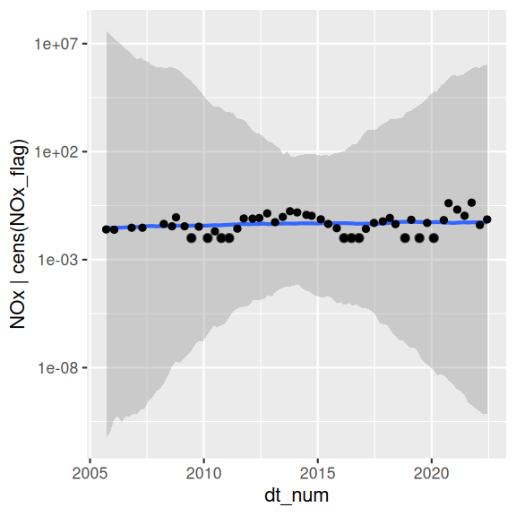

```r
wq_brm1 |> conditional_effects() |>
  ## plot(points=TRUE, point_args = list(colour = "red", size = 4)) |>
  plot(points=TRUE) |>
  _[[1]] +
  scale_y_log10() +
  geom_point(data = wq_sub, inherit.aes = FALSE,
             aes(y = NOx, x = dt_num))
```

**Sample prior and posterior**

```r
wq_brm2 <- update(wq_brm1, sample_prior = "yes", cores =  3, seed = 123, refresh =  0)
```

```
The desired updates require recompiling the model
```

```
Ignoring unknown labels:
• fill : "NA"
• colour : "NA"
Ignoring unknown labels:
• fill : "NA"
• colour : "NA"
```

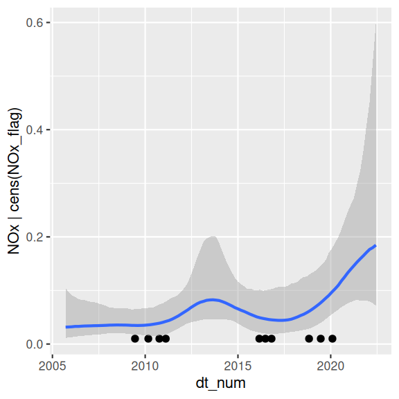

```
Ignoring unknown labels:
• fill : "NA"
• colour : "NA"
```

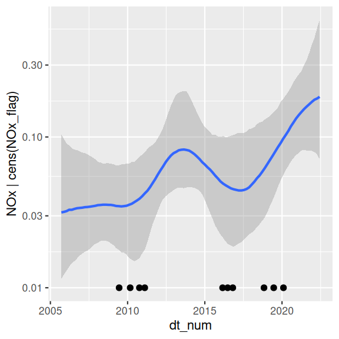

```r
wq_brm2 |> conditional_effects() |>  plot(points=TRUE) |>
  _[[1]] +
  scale_y_log10()
```

```
Ignoring unknown labels:
• fill : "NA"
• colour : "NA"
Ignoring unknown labels:
• fill : "NA"
• colour : "NA"
```

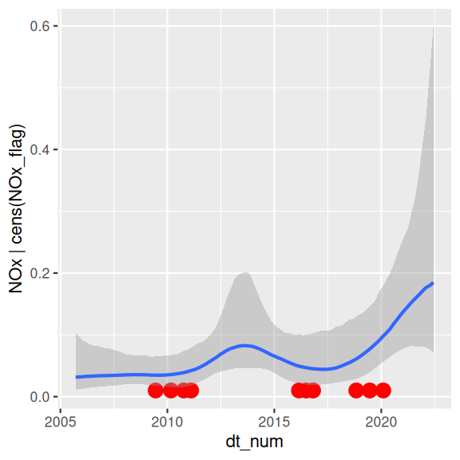

```
Ignoring unknown labels:
• fill : "NA"
• colour : "NA"
```

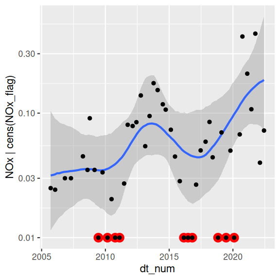

```r
wq_brm2 |> conditional_effects() |>
  plot(points=TRUE, point_args = list(colour = "red", size = 4)) |>
  _[[1]] +
  scale_y_log10() +
  geom_point(data = wq_sub, inherit.aes = FALSE,
             aes(y = NOx, x = dt_num))
```

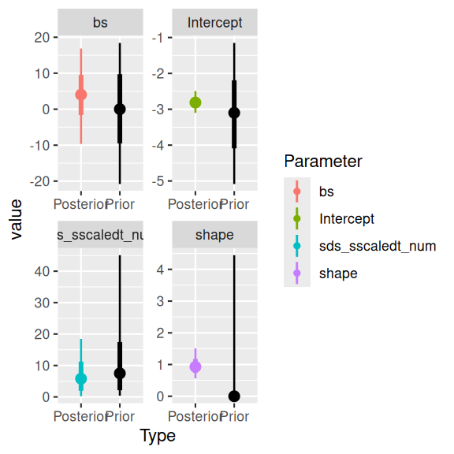

```r
wq_brm2 |> SUYR_prior_and_posterior()
```

```
Ignoring unknown labels:
• colour : "NA"
Ignoring unknown labels:
• colour : "NA"
```

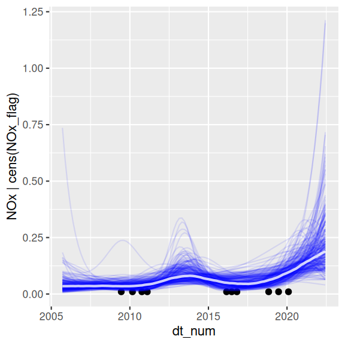

```
Ignoring unknown labels:
• colour : "NA"
```

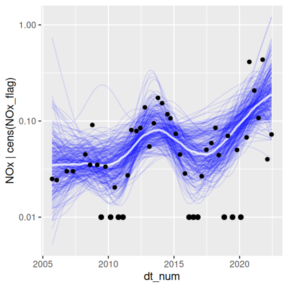

```r
wq_brm2 |> conditional_effects(spaghetti = TRUE, ndraws =  250) |>  plot(points=TRUE) |>
  _[[1]] +
  scale_y_log10() +
  geom_point(data = wq_sub, inherit.aes = FALSE,
             aes(y = NOx, x = dt_num))
```

```
Ignoring unknown labels:
• fill : "NA"
• colour : "NA"
Ignoring unknown labels:
• fill : "NA"
• colour : "NA"
```

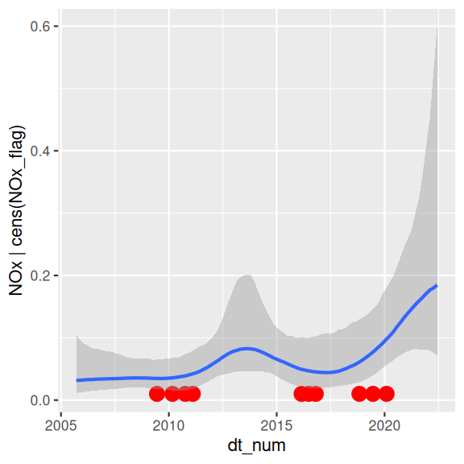

```
Ignoring unknown labels:
• fill : "NA"
• colour : "NA"
```

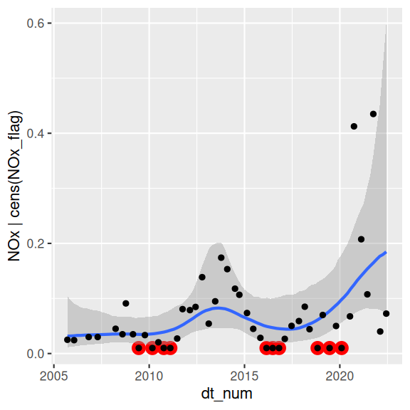

```r
wq_brm2 |> conditional_effects() |>
  plot(points=TRUE, point_args = list(colour = "red", size = 4)) |>
  _[[1]] +
  geom_point(data = wq_sub, inherit.aes = FALSE,
             aes(y = NOx, x = dt_num))
```

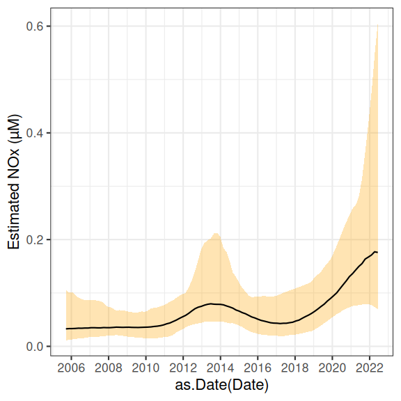

```r
## semi-manual plot
wq_brm2 |>
    conditional_effects(spaghetti = TRUE, ndraws = 250) |>
  as_draws_df() |>
  mutate(across(c(dt_num, estimate__, lower__, upper__), as.numeric)) |>
  mutate(Date =  lubridate::date_decimal(dt_num)) |>
  ggplot(aes(x = as.Date(Date), y = estimate__)) +
  geom_ribbon(aes(ymin = lower__, ymax = upper__), fill = "orange", alpha = 0.3) +
  geom_line() +
  scale_y_continuous("Estimated NOx (µM)") +
  scale_x_date(date_breaks = "2 years", date_labels = "%Y") +
  theme_bw()
```

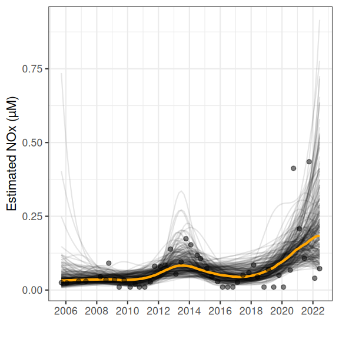

```r
# semi-manual spaghetti plot
newdata <- with(wq_sub, tibble(dt_num = seq(min(dt_num), max(dt_num), length = 100))) |>
  mutate(Date = as.Date(lubridate::date_decimal(dt_num)))
wq_brm2 |>
  add_epred_draws(newdata = newdata) |>
  filter(.draw < 250) |>
  ggplot(aes(x = Date, y = .epred, group = .draw)) +
  geom_line(alpha = 0.1) +
  stat_summary(
    aes(group = 1),
    fun = median,
    geom = "line",
    color = "orange",
    linewidth = 1
  ) +
  geom_point(data = wq_sub, inherit.aes = FALSE,
             aes(x = Date, y = NOx), alpha = 0.5) +
  scale_x_date("", date_breaks = "2 years", date_labels = "%Y") +
  ## scale_y_log10() +
  scale_y_continuous("Estimated NOx (µM)") +
  theme_bw()
```

**MCMC sampling diagnostics**

**stan plots**

```
'pars' not specified. Showing first 10 parameters by default.
```

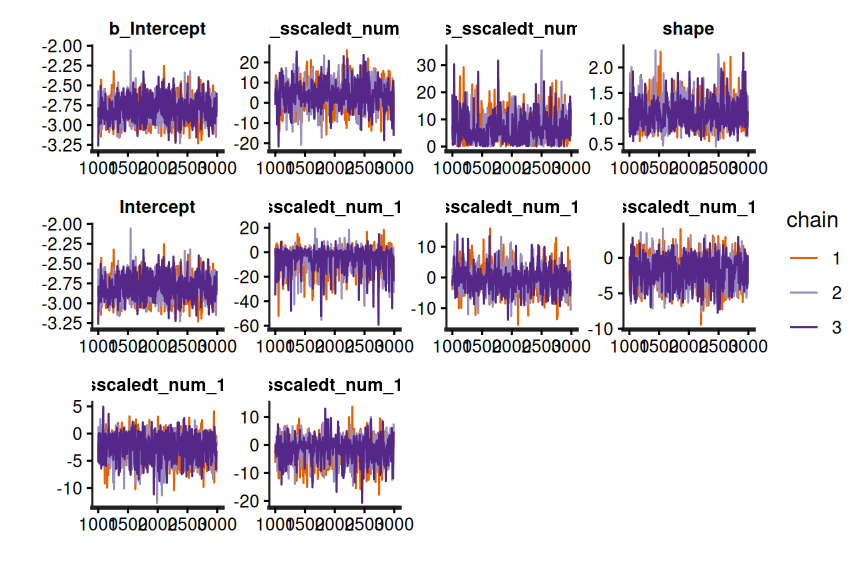

```r
wq_brm2$fit |> stan_trace()
```

```
'pars' not specified. Showing first 10 parameters by default.
```

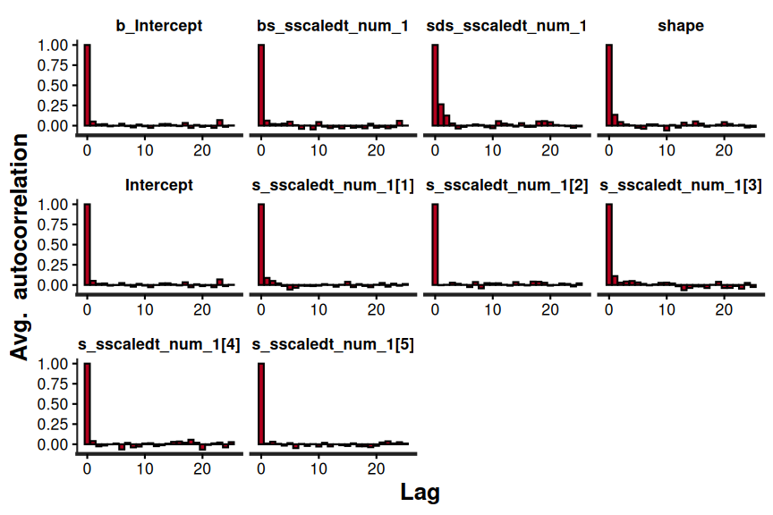

```r
wq_brm2$fit |> stan_ac()
```

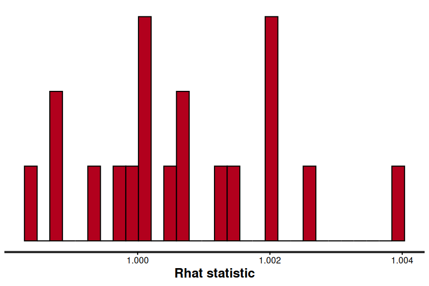

```r
wq_brm2$fit |> stan_rhat()
```

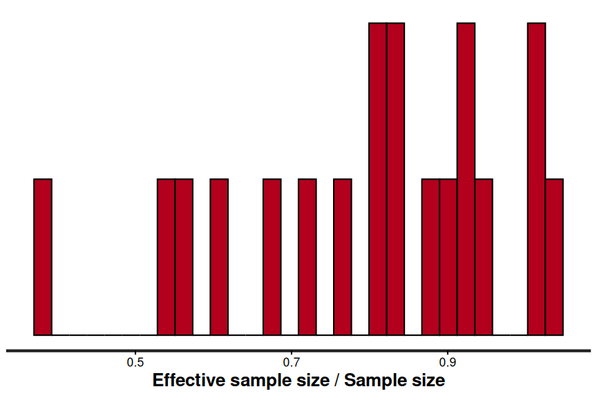

```r
wq_brm2$fit |> stan_ess()
```

**Model validation**

**pp check**

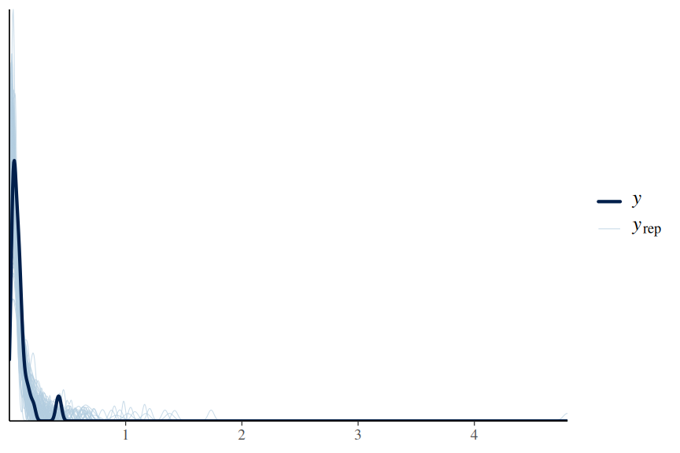

```r
wq_brm2 |> pp_check( type='dens_overlay', ndraws=100)
```

**DHARMa residuals**

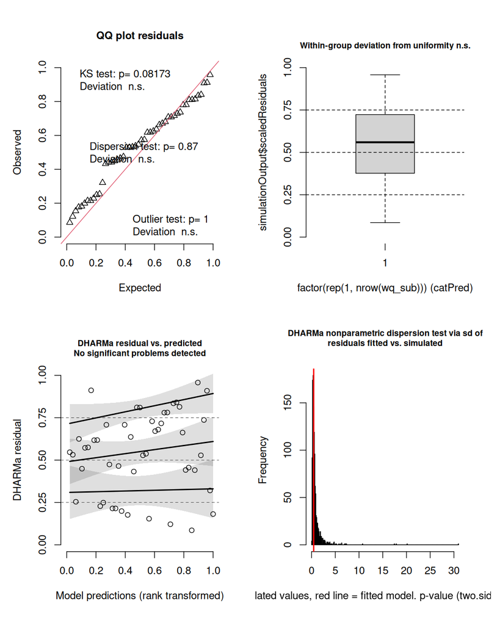

```r
wq_resids <- make_brms_dharma_res(wq_brm2, integerResponse = FALSE)
wrap_elements(~testUniformity(wq_resids)) +
  wrap_elements(~plotResiduals(wq_resids, form = factor(rep(1, nrow(wq_sub))))) +
  wrap_elements(~plotResiduals(wq_resids, quantreg = TRUE)) +
  wrap_elements(~testDispersion(wq_resids))
```

**Partial effects plots**

```
Ignoring unknown labels:
• fill : "NA"
• colour : "NA"
Ignoring unknown labels:
• fill : "NA"
• colour : "NA"
```

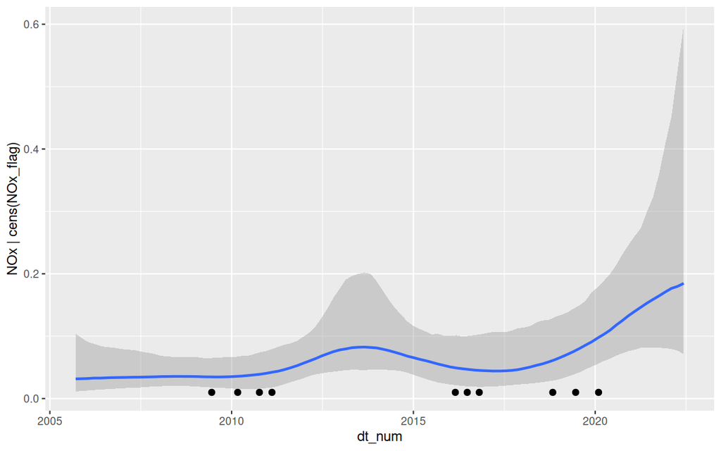

```r
wq_brm2 |> conditional_effects() |> plot(points = TRUE)
```

```
Ignoring unknown labels:
• colour : "NA"
Ignoring unknown labels:
• colour : "NA"
```

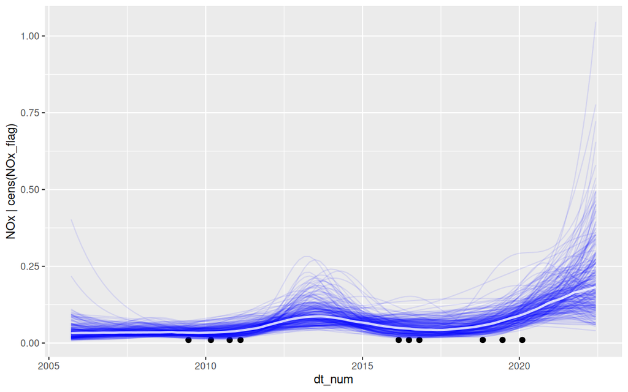

```r
wq_brm2 |>
    conditional_effects(spaghetti = TRUE, ndraws = 250) |>
    plot(points = TRUE)
```

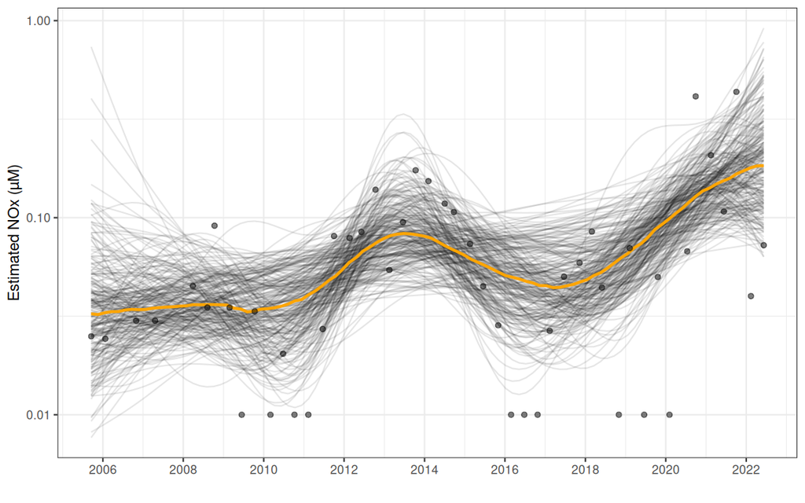

```r
newdata <- with(wq_sub, tibble(dt_num = seq(min(dt_num), max(dt_num), length = 100))) |>
  mutate(Date = as.Date(lubridate::date_decimal(dt_num)))
# semi-manual spaghetti plot
wq_brm2 |>
  add_epred_draws(newdata = newdata) |>
  filter(.draw < 250) |>
  ggplot(aes(x = Date, y = .epred, group = .draw)) +
  geom_line(alpha = 0.1) +
  stat_summary(
    aes(group = 1),
    fun = median,
    geom = "line",
    color = "orange",
    linewidth = 1
  ) +
  geom_point(data = wq_sub, inherit.aes = FALSE,
             aes(x = Date, y = NOx), alpha = 0.5) +
  scale_x_date("", date_breaks = "2 years", date_labels = "%Y") +
  ## scale_y_log10() +
  scale_y_log10("Estimated NOx (µM)") +
  theme_bw()
```

**Model investigation**

**Summary**

```r
wq_brm2 |> summary()
```

```
 Family: gamma
  Links: mu = log
Formula: NOx | cens(NOx_flag) ~ s(scale(dt_num))
   Data: wq_sub (Number of observations: 48)
  Draws: 3 chains, each with iter = 3000; warmup = 1000; thin = 5;
         total post-warmup draws = 1200

Smoothing Spline Hyperparameters:
                    Estimate Est.Error l-95% CI u-95% CI Rhat Bulk_ESS Tail_ESS
sds(sscaledt_num_1)     6.71      5.04     0.21    18.46 1.00      577      872

Regression Coefficients:
               Estimate Est.Error l-95% CI u-95% CI Rhat Bulk_ESS Tail_ESS
Intercept         -2.81      0.15    -3.10    -2.49 1.00     1022     1167
sscaledt_num_1     4.03      6.44    -9.66    16.88 1.00      984     1053

Further Distributional Parameters:
      Estimate Est.Error l-95% CI u-95% CI Rhat Bulk_ESS Tail_ESS
shape     1.11      0.28     0.66     1.78 1.00      899     1082

Draws were sampled using sampling(NUTS). For each parameter, Bulk_ESS
and Tail_ESS are effective sample size measures, and Rhat is the potential
scale reduction factor on split chains (at convergence, Rhat = 1).
```

- sds(sx_1) is the sd of the smooth weights (spline coefficients).
  - This determines the amount of ‘wiggliness’, and is analogous way to how the sd of group-level effects in a varying slopes and intercepts model determine the amount of variability among groups in slopes and intercepts.
  - However, the actual numeric value of the sds() is not very practically interpretable, because thinking about the variance of smooth weights for any given data and model seems abstract to me.
  - However, if the value is around zero, then this is like ‘complete-pooling’ of the basis functions, which means that there isn’t much added value of more than a single basis function.
- sx_1 is the unpenalized weight (ie coefficient) for one of the “natural” parameterized basis functions.
  - The rest of the basis functions are like varying effects.
  - Again, because the actual numeric value of sxs_1 is the value for the unpenalized coefficient for one of the basis functions.
  - his wouldn’t seem to have a lot of practically interpretable meaning just from viewing this number.

**summarise_draws**

```r
wq_brm2 |> as.data.frame() |>
  dplyr::select(matches("^b_.*|^bs.*|^sds.*|^shape$|^s_s.*")) |>
  summarise_draws(median,
    HDInterval::hdi)
```

```
# A tibble: 12 × 4
   variable            median    lower upper
   <chr>                <dbl>    <dbl> <dbl>
 1 b_Intercept         -2.81   -3.11   -2.52
 2 bs_sscaledt_num_1    4.04  -10.0    16.0
 3 sds_sscaledt_num_1   5.79    0.0229 15.7
 4 shape                1.08    0.592   1.61
 5 s_sscaledt_num_1[1] -2.11  -25.4     9.05
 6 s_sscaledt_num_1[2] -0.462  -9.07    7.06
 7 s_sscaledt_num_1[3] -1.70   -5.99    1.97
 8 s_sscaledt_num_1[4] -2.18   -7.47    1.70
 9 s_sscaledt_num_1[5] -0.931 -12.0     6.08
10 s_sscaledt_num_1[6]  8.44   -1.62   27.0
11 s_sscaledt_num_1[7] -0.549 -15.1    13.3
12 s_sscaledt_num_1[8] -1.04  -19.0    10.6
```

**Find the peak**

```r
newdata <- with(wq_sub, data.frame(
  dt_num = seq(min(2010), max(2017), length = 1000)
))
wq_peak <-
    add_epred_draws(
        object = wq_brm2, newdata = newdata,
        re_formula = NA,
        ndraws = 1000
    ) |>
    ungroup() |>
    group_by(.draw) |>
  summarise(x = dt_num[which.max(.epred)],
    Nox = .epred[which.max(.epred)],
    .groups = "keep") |>
    ungroup() |>
  median_hdci(.width = 0.95) |>
  mutate(across(matches("^x"), lubridate::date_decimal)) |>
  mutate(across(matches("^x"), as.Date)) |>
  as.data.frame()
wq_peak
```

```
           x    x.lower    x.upper        Nox  Nox.lower Nox.upper .width
1 2013-09-21 2012-08-10 2017-01-01 0.09018133 0.04771352  0.186602   0.95
  .point .interval
1 median      hdci
```

```r
## wq_peak <-
##     add_epred_draws(
##         object = wq_brm2, newdata = newdata,
##         re_formula = NA,
##         ndraws = 1000
##     ) |>
##     ungroup() |>
##     group_by(.draw) |>
##   summarise(x = dt_num[which.max(.epred)],
##     Nox = .epred[which.max(.epred)],
##     .groups = "keep") |>
##     ungroup() |>
##   pivot_longer(cols = c(x, Nox), names_to = "variable", values_to = "value") |>
##     group_by(variable) |>
##   median_hdci(.width = 0.95) |>
##   as.data.frame()
## wq_peak
```

**Gaussian Process**

**Priors**

Choosing a prior for the GP length scale:

For an exponentiated-quadratic Gaussian process, the correlation between two observations separated by distance $d$ is:

$$\rho(d) = \exp\left[ -\frac{1}{2} \left(\frac{d}{\ell}\right)^2 \right],$$

where $\ell$ is the GP length scale, called `lscale` in brms.

The length scale controls how quickly the fitted relationship can change:

- small lscale: rapid, local variation
- large lscale: broad, smooth variation

at a distance equal to `lscale`, the correlation is approximately 0.61.

When `gp(x, scale = TRUE)` is used, distances are expressed as proportions of the observed range of `x`. Thus, a distance of 0.2 represents 20% of the observed predictor range.

Specifying an ecologically meaningful prior:

Rather than selecting inverse-gamma parameters directly, consider the distance at which the GP correlation becomes weak. We define weak correlation as:

$$\rho_{\text{weak}}=0.1.$$

The distance at which correlation reaches a specified value is:
$$d_{\text{weak}} = \ell\sqrt{-2\log(\rho_{\text{weak}})}$$

For $\rho_{\text{weak}}=0.1$, $d_{\text{weak}}\approx2.146\ell$, or equivalently, $\ell\approx\frac{d_{\text{weak}}}{2.146}$.

Use `invgamma_from_weak_distance()` to specify a plausible range for $d_{\text{weak}}$. For example:

```r
invgamma_from_weak_distance(
  lower_distance = 0.20,
  upper_distance = 0.75,
  weak_correlation = 0.10,
  probability = 0.90
)
```

```
$shape
[1] 6.611497

$scale
[1] 1.055846

$weak_correlation
[1] 0.1

$probability
[1] 0.9

$lscale_quantiles
     lower     median      upper
0.09319812 0.16809301 0.34949287

$weak_distance_quantiles
    lower    median     upper
0.2000000 0.3607219 0.7499998

$prior
[1] "inv_gamma(6.611497, 1.055846)"
```

This expresses the prior belief:

There is 90% prior probability that GP correlation falls to 0.1 after a separation between 20% and 75% of the observed predictor range.